# Kakamega semi-omission trials analysis

Author

Lavinia Madaga

# 1 Introduction

This analysis uses data from on-farm trials conducted in Kakamega county during the 2025 long rains season (April–September). Data were collected from nine farms. The experiment was implemented as a split-plot design, with two lime rates (0 and 2 t/ha) assigned to the main plots, and nitrogen (N) and phosphorus (P) treatments applied to subplots. The subplot treatments consisted of: control (no N or P), N only (123 kg N/ha), P only (50 kg P/ha), and a combination of N and P at the respective rates. Potassium (K) was also applied uniformly across all plots at 40 kg K/ha, including the control.

This notebook summarises maize yield and post-harvest soil property responses to these treatments. A linear mixed-effects model was adopted to evaluate treatment effects while accounting for variability between farms.

The yield model is specified as:

$$GY \sim N \times P \times Lime + (1 \mid Farm)$$

## 1.1 Data preparation

```r
library(tidyverse)
library(data.table)
library(writexl)
library(tibble)
library(janitor)
library(gt)
library(lmerTest)
library(emmeans)
library(multcomp)
library(ggplot2)
library(patchwork)
```

These datasets contain topsoil, subsoil, and post-harvest soil data, along with agronomic trial data.

```r
top  <- read.csv("Top_soil_1.csv")

sub  <- read.csv("Sub-soil_1.csv")

post <- read.csv("Post_harvest_soil.csv")

semi_data <- read.csv("Kakamega_semi_ommisions_season_1_with_post_soil.csv")
```

```r
# Specify farm ID for each of the datasets
semi_data <- semi_data %>%
  mutate(FarmID = as.numeric(str_extract(Farmer_code, "[0-9]+$")))
# unique(semi_data$FarmID)

# topsoil
top_clean <- top %>%
  rename(sample_id = sample.code) %>%
  mutate(
    FarmID = as.numeric(sample_id),
    village = str_to_lower(village) %>% str_replace_all("'", "") %>% str_trim())
# unique(top_clean$FarmID)

# subsoil
sub_clean <- sub %>%
  rename(sample_id = soil_sample_code) %>%
  mutate(
    FarmID = as.numeric(str_remove(sample_id, "S")),
    village = str_to_lower(village) %>% str_replace_all("_", " ") %>% str_trim())
# unique(sub_clean$FarmID)

# post-harvest (at plot-level)
post_clean <- post %>%
  mutate(
    # Extract the number that immediately precedes "-plot"
    FarmID = as.numeric(str_extract(Sample_Code, "(?<=-)[0-9]+(?=-plot)")),
    # Reconstruct Farmer_Code
    Farmer_Code = str_remove(Sample_Code, "-plot[0-9]+$"))
# print(unique(post_clean$FarmID))
```

```r
# Rename all soil variables
# function to rename everything except IDs
rename_with_suffix <- function(df, suffix) {
  df %>%
    rename_with(~ paste0(., "_", suffix), -FarmID)
}

top_renamed <- rename_with_suffix(top_clean, "top")
sub_renamed <- rename_with_suffix(sub_clean, "sub")
post_renamed <- post_clean %>%
  rename_with(~ paste0(., "_post"), -c(Sample_Code, FarmID))

# Merge everything by farm ID
semi_data_with_soil <- semi_data %>%
  left_join(top_renamed, by = "FarmID") %>%
  left_join(sub_renamed, by = "FarmID") %>%
  left_join(post_renamed, by = c("Sample_Code", "FarmID"))

# write.csv(semi_data_with_soil, "semi_data_with_soil.csv", row.names = FALSE)
```

```r
# Clean up soil property names
semi_data_with_soil_clean <- semi_data_with_soil %>%
  clean_names() %>%
  rename_with(~ str_replace_all(., "soc____", "soc_pct")) %>%
  rename_with(~ str_replace_all(., "tn____", "tn_pct")) %>%
  rename_with(~ str_replace_all(., "clay____", "clay_pct")) %>%
  rename_with(~ str_replace_all(., "silt____", "silt_pct")) %>%
  rename_with(~ str_replace_all(., "sand____", "sand_pct")) %>%

  rename_with(~ str_replace_all(., "ph_", "ph_")) %>%

  # Fix mg/kg naming
  rename_with(~ str_replace_all(., "mg_kg_", "mgkg_")) %>%

  # Final cleanup
  rename_with(~ str_replace_all(., "__", "_"))

# CREATE CMOL VARIABLES
semi_data_with_soil_clean_2 <- semi_data_with_soil_clean %>%
  mutate(
    # ---------- TOPSOIL ----------
    ca_cmol_top = ca_mgkg_top / 200,
    mg_cmol_top = mg_mgkg_top / 122,
    k_cmol_top  = k_mgkg_top  / 390,
    na_cmol_top = na_mgkg_top / 230,
    al_cmol_top = al_mgkg_top / 90,
    # ---------- SUBSOIL ----------
    ca_cmol_sub = m3_ca_mgkg_sub / 200,
    mg_cmol_sub = m3_mg_mgkg_sub / 122,
    k_cmol_sub  = m3_k_mgkg_sub  / 390,
    na_cmol_sub = m3_na_mgkg_sub / 230,
    al_cmol_sub = m3_al_mgkg_sub / 90,
    # ---------- POST ----------
    ca_cmol_post = m3_ca_mgkg_post / 200,
    mg_cmol_post = m3_mg_mgkg_post / 122,
    k_cmol_post  = m3_k_mgkg_post  / 390,
    na_cmol_post = m3_na_mgkg_post / 230,
    al_cmol_post = m3_al_mgkg_post / 90)

# Calculate  ECEC + Hp Sat
semi_data_with_soil_clean_2 <- semi_data_with_soil_clean_2 %>%
  mutate(

    # ---------- TOP ----------
    ecec_top = ex_ac_cmolc_kg_top + ca_cmol_top + mg_cmol_top + k_cmol_top + na_cmol_top,
    hp_sat_top = 100 * ex_ac_cmolc_kg_top / ecec_top,

    # ---------- SUB ----------
    ecec_sub = ex_ac_cmolc_kg_sub + ca_cmol_sub + mg_cmol_sub + k_cmol_sub + na_cmol_sub,
    hp_sat_sub = 100 * ex_ac_cmolc_kg_sub / ecec_sub,

    # ---------- POST ----------
    ecec_post = ex_ac_cmolc_kg_post + ca_cmol_post + mg_cmol_post + k_cmol_post + na_cmol_post,
    hp_sat_post = 100 * ex_ac_cmolc_kg_post / ecec_post)

#summary(semi_data_with_soil_clean_2$ecec_top)
#summary(semi_data_with_soil_clean_2$ecec_sub)
#summary(semi_data_with_soil_clean_2$hp_sat_top)
#names(semi_data_with_soil_clean_2)

write.csv(semi_data_with_soil_clean_2, "semi_data_with_soil_clean_2_clean.csv", row.names = FALSE)

c <- read.csv("semi_data_with_soil_clean_2_clean.csv")

c <- c %>%
  rename(
    ph_top = p_h_top,
    ph_sub = p_h_sub,
    ph_post = p_h_post)

c <- c %>%
  rename(
    soc_top_pct = soc_top,
    tn_top_pct = tn_top,
    soc_sub_pct = soc_sub,
    tn_sub_pct = tn_sub,
    soc_post_pct = soc_post,
    tn_post_pct = tn_post,

    ecec_top_cmolkg = ecec_top,
    ecec_sub_cmolkg = ecec_sub,
    ecec_post_cmolkg = ecec_post,

    hp_sat_top_pct = hp_sat_top,
    hp_sat_sub_pct = hp_sat_sub,
    hp_sat_post_pct = hp_sat_post)

# write.csv(c, "semi_data_with_soil_clean.csv", row.names = FALSE)
```

Grain yield is standardised to 15% moisture content and then converted from kg/plot to t/ha.

```r
# Prepare yield
semi <- read.csv("semi_data_with_soil_clean.csv")

# Calculate Standardized Grain Yield (GY) at 15% Moisture.
# Using the formula: cob_grain_fw * ((100 - Current_GM) / (100 - 15))
semi$GY <- semi$cob_grain_fw * ((100 - semi$grain_moisture) / 85)

# Convert kg/plot to t/ha
semi$GY_tha <- semi$GY / 3

head(semi[, c("cob_grain_fw", "grain_moisture", "GY", "GY_tha")])
```

```
  cob_grain_fw grain_moisture       GY   GY_tha
1         25.9           34.6 19.92776 6.642588
2         23.4           32.9 18.47224 6.157412
3         16.9           29.1 14.09659 4.698863
4         26.7           35.6 20.22918 6.743059
5         19.8           33.8 15.42071 5.140235
6         25.6           29.8 21.14259 7.047529
```

```r
# Save the updated dataset
# write.csv(semi, "Semi_ommisions_data_season_1_with_post_soil_clean.csv", row.names = FALSE)
```

## 1.2 Baseline soil properties by farm and depth

```r
semi <- read.csv("Semi_ommisions_data_season_1_with_post_soil_clean.csv")

# Keep one row per farm since initial soil values are repeated across plots
farm_soil <- semi %>% distinct(farm_id, .keep_all = TRUE)

# Topsoil table
top_tbl <- farm_soil %>%
  transmute(
    `Farm ID` = farm_id,
    `Depth (cm)` = "0-20",
    `Clay + silt (%)` = clay_top + silt_top,
    `SOC (%)` = soc_top_pct,
    `pH (H2O)` = ph_top,
    `Exch. Ca (cmol/kg)` = ca_cmol_top,
    `Exch. Mg (cmol/kg)` = mg_cmol_top,
    `Exch. acidity (cmol/kg)` = ex_ac_cmolc_kg_top,
    `ECEC (cmol/kg)` = ecec_top_cmolkg,
    `Acidity saturation (%)` = hp_sat_top_pct,
    `Ca saturation (%)` = 100 * ca_cmol_top / ecec_top_cmolkg,
    `PSI` = psi_top)

# Subsoil table
sub_tbl <- farm_soil %>%
  transmute(
    `Farm ID` = farm_id,
    `Depth (cm)` = "30-50",
    `Clay + silt (%)` = clay_sub + silt_sub,
    `SOC (%)` = soc_sub_pct,
    `pH (H2O)` = ph_sub,
    `Exch. Ca (cmol/kg)` = ca_cmol_sub,
    `Exch. Mg (cmol/kg)` = mg_cmol_sub,
    `Exch. acidity (cmol/kg)` = ex_ac_cmolc_kg_sub,
    `ECEC (cmol/kg)` = ecec_sub_cmolkg,
    `Acidity saturation (%)` = hp_sat_sub_pct,
    `Ca saturation (%)` = 100 * ca_cmol_sub / ecec_sub_cmolkg,
    `PSI` = psi_sub)

# Combine topsoil first, then subsoil
initial_soil_table <- bind_rows(top_tbl, sub_tbl) %>%
  mutate(`Depth (cm)` = factor(`Depth (cm)`, levels = c("0-20", "30-50"))) %>%
  arrange(`Depth (cm)`, `Farm ID`) %>%
  mutate(
    across(where(is.numeric), ~ round(., 2)))

# Create a nice gt table
soil_gt <- initial_soil_table %>%
  gt(groupname_col = "Depth (cm)") %>%
  tab_header(
    title = md("**Initial soil properties by farm and depth**"),
    subtitle = "Topsoil (0-20 cm) and subsoil (30-50 cm)"
  ) %>%
  cols_align(
    align = "center",
    columns = everything()
  ) %>%
  fmt_number(
    columns = c(
      `Clay + silt (%)`, `SOC (%)`, `pH (H2O)`,
      `Exch. Ca (cmol/kg)`, `Exch. Mg (cmol/kg)`,
      `Exch. acidity (cmol/kg)`, `ECEC (cmol/kg)`,
      `Acidity saturation (%)`, `Ca saturation (%)`, `PSI`),
    decimals = 2
  ) %>%
  tab_options(
    table.font.size = 12,
    data_row.padding = px(4),
    heading.align = "center")

#| label: show-initial-soil-table
#| tbl-cap: "Initial soil properties for each farm at topsoil (0-20 cm) and subsoil (30-50 cm) depths."

soil_gt
```

**Initial soil properties by farm and depth**

Topsoil (0-20 cm) and subsoil (30-50 cm)

| Farm ID | Clay + silt (%) | SOC (%) | pH (H2O) | Exch. Ca (cmol/kg) | Exch. Mg (cmol/kg) | Exch. acidity (cmol/kg) | ECEC (cmol/kg) | Acidity saturation (%) | Ca saturation (%) | PSI |
| --- | --- | --- | --- | --- | --- | --- | --- | --- | --- | --- |
| 0-20 |  |  |  |  |  |  |  |  |  |  |
| 5 | 78.36 | 1.87 | 5.19 | 5.76 | 1.43 | 0.32 | 8.00 | 4.00 | 71.96 | 107.36 |
| 10 | 83.00 | 2.27 | 5.57 | 5.39 | 1.62 | 0.16 | 7.75 | 2.07 | 69.63 | 85.60 |
| 11 | 87.62 | 2.40 | 5.16 | 4.60 | 1.30 | 0.47 | 6.89 | 6.82 | 66.70 | 135.78 |
| 18 | 72.52 | 1.73 | 5.25 | 3.96 | 0.90 | 0.16 | 5.37 | 2.98 | 73.74 | 96.50 |
| 22 | 76.91 | 1.52 | 5.28 | 3.40 | 1.39 | 0.33 | 5.67 | 5.82 | 59.99 | 111.81 |
| 35 | 87.22 | 2.08 | 5.02 | 3.32 | 1.07 | 0.74 | 5.53 | 13.39 | 60.17 | 157.36 |
| 45 | 76.70 | 1.51 | 5.18 | 4.36 | 1.13 | 0.20 | 6.15 | 3.25 | 70.82 | 114.14 |
| 52 | 62.59 | 0.82 | 5.10 | 3.18 | 0.93 | 0.36 | 4.80 | 7.49 | 66.30 | 72.24 |
| 58 | 87.02 | 1.62 | 5.16 | 4.26 | 1.87 | 0.33 | 6.88 | 4.80 | 61.90 | 162.83 |
| 30-50 |  |  |  |  |  |  |  |  |  |  |
| 5 | 86.56 | 1.73 | 5.77 | 8.31 | 1.15 | 0.29 | 10.45 | 2.78 | 79.56 | 144.48 |
| 10 | 82.78 | 1.69 | 5.71 | 6.49 | 1.19 | 0.40 | 8.69 | 4.61 | 74.71 | 90.47 |
| 11 | 91.27 | 1.86 | 5.84 | 8.25 | 0.46 | 0.28 | 9.64 | 2.90 | 85.53 | 188.21 |
| 18 | 75.25 | 1.47 | 5.47 | 3.92 | 1.14 | 0.36 | 5.92 | 6.08 | 66.23 | 91.11 |
| 22 | 76.14 | 1.00 | 5.30 | 1.98 | 0.42 | 0.50 | 3.35 | 14.94 | 59.03 | 118.51 |
| 35 | 90.44 | 1.81 | 5.20 | 5.56 | 0.56 | 0.58 | 7.15 | 8.11 | 77.72 | 196.19 |
| 45 | 86.75 | 1.33 | 5.24 | 3.05 | 0.36 | 0.65 | 4.59 | 14.16 | 66.55 | 177.18 |
| 52 | 66.12 | 0.72 | 5.70 | 2.77 | 1.04 | 0.42 | 4.75 | 8.85 | 58.35 | 88.46 |
| 58 | 85.38 | 1.40 | 5.75 | 4.56 | 1.12 | 0.34 | 6.62 | 5.13 | 68.83 | 152.31 |

## 1.3 Maize yield analysis using a linear mixed model

The yield analysis treats farm as a random effect and tests the effects of lime, N, P, and their interactions.

```r
# Prepare data
df <- semi %>%
  mutate(
    N_rate = factor(n_rate),
    P_rate = factor(p_rate),
    Lime_rate = factor(lime),
    Farmer_code = factor(farmer_code))

# Helper functions
format_p <- function(p){
  if(is.na(p)) return(NA)
  if(p < 0.001) return("<0.001")
  sprintf("%.3f", p)
}

calc_lsd <- function(em){
  pairs_em <- pairs(em)
  df1 <- summary(em)$df[1]
  tcrit <- qt(0.975, df1)
  SE <- mean(summary(pairs_em)$SE, na.rm = TRUE)
  round(tcrit * SE, 2)
}

calc_cv <- function(model, data, var_name){
  res_sd <- sigma(model)
  mean_val <- mean(data[[var_name]], na.rm = TRUE)
  round((res_sd / mean_val) * 100, 2)
}


# Fit Linear mixed model
model <- lmerTest::lmer(
  GY_tha ~ N_rate * P_rate * Lime_rate + (1 | Farmer_code),
  data = df,
  REML = TRUE)

# summary(model)
anova_tab <- anova(model, type = 3)
anova_tab
```

```
Type III Analysis of Variance Table with Satterthwaite's method
                        Sum Sq Mean Sq NumDF  DenDF F value   Pr(>F)
N_rate                  78.614  78.614     1 54.978 33.5319  3.5e-07 ***
P_rate                  17.949  17.949     1 54.978  7.6561 0.007693 **
Lime_rate               11.673  11.673     1 54.978  4.9789 0.029756 *
N_rate:P_rate           10.888  10.888     1 54.978  4.6442 0.035555 *
N_rate:Lime_rate         3.704   3.704     1 54.978  1.5800 0.214072
P_rate:Lime_rate         0.006   0.006     1 54.978  0.0024 0.961226
N_rate:P_rate:Lime_rate  0.360   0.360     1 54.978  0.1536 0.696588
---
Signif. codes:  0 '***' 0.001 '**' 0.01 '*' 0.05 '.' 0.1 ' ' 1
```

Estimated marginal means and treatment groupings for yield.

```r
# Estimated marginal means
em_lime <- emmeans(model, ~ Lime_rate)
em_n <- emmeans(model, ~ N_rate)
em_p <- emmeans(model, ~ P_rate)
em_np <- emmeans(model, ~ N_rate * P_rate | Lime_rate)
em_all <- emmeans(model, ~ N_rate * P_rate * Lime_rate)

# Letters for full treatment combinations
gy_letters <- multcomp::cld(em_all, Letters = letters) %>%
  as.data.frame() %>%
  mutate(
    .group = trimws(.group),
    N_rate = factor(N_rate),
    P_rate = factor(P_rate),
    Lime_rate = factor(Lime_rate),
    treatment = case_when(
      N_rate == "0"   & P_rate == "0"  ~ "Control",
      N_rate != "0"   & P_rate == "0"  ~ "N only",
      N_rate == "0"   & P_rate != "0"  ~ "P only",
      N_rate != "0"   & P_rate != "0"  ~ "N + P"))
# gy_letters

means_export <- gy_letters %>%
  dplyr::select(
    Lime_rate, N_rate, P_rate, treatment,
    emmean, SE, df, lower.CL, upper.CL, .group
  ) %>%
  rename(
    Lime = Lime_rate,
    N = N_rate,
    P = P_rate,
    Mean = emmean,
    Letters = .group)

# means_export
```

## 1.4 Yield means table

```r
means_export %>%
  mutate(
    Mean = round(Mean, 2),
    SE = round(SE, 2),
    df = round(df, 2),
    lower.CL = round(lower.CL, 2),
    upper.CL = round(upper.CL, 2)
  ) %>%
  gt() %>%
  tab_header(
    title = md("**Estimated marginal means for maize yield**"),
    subtitle = "Yield means and compact letter display"
  ) %>%
  cols_align(
    align = "center",
    columns = everything()
  ) %>%
  tab_options(
    table.font.size = 12,
    data_row.padding = px(4),
    heading.align = "center")
```

Estimated marginal means for maize yield across lime, nitrogen and phosphorus treatments.

**Estimated marginal means for maize yield**

Yield means and compact letter display

| Lime | N | P | treatment | Mean | SE | df | lower.CL | upper.CL | Letters |
| --- | --- | --- | --- | --- | --- | --- | --- | --- | --- |
| 0 | 0 | 0 | Control | 3.03 | 0.84 | 19.22 | 1.26 | 4.79 | a |
| 0 | 0 | 50 | P only | 3.38 | 0.82 | 17.53 | 1.65 | 5.11 | a |
| 2 | 0 | 0 | Control | 3.51 | 0.82 | 17.53 | 1.78 | 5.24 | ab |
| 2 | 0 | 50 | P only | 3.61 | 0.82 | 17.53 | 1.88 | 5.34 | ab |
| 0 | 123 | 0 | N only | 4.04 | 0.82 | 17.53 | 2.31 | 5.77 | ab |
| 2 | 123 | 0 | N only | 5.15 | 0.82 | 17.53 | 3.42 | 6.88 | abc |
| 0 | 123 | 50 | N + P | 5.67 | 0.82 | 17.53 | 3.94 | 7.40 | bc |
| 2 | 123 | 50 | N + P | 7.10 | 0.82 | 17.53 | 5.37 | 8.83 | c |

```r
results_table <- gy_letters %>%
  mutate(
    omit_treatment = case_when(
      N_rate == "0"   & P_rate == "0"  ~ "Control",
      N_rate != "0"   & P_rate == "0"  ~ "N only",
      N_rate == "0"   & P_rate != "0"  ~ "P only",
      N_rate != "0"   & P_rate != "0"  ~ "N + P"
    ),
    Mean_letter = paste0(round(emmean, 2), " ", .group)
  ) %>%
  dplyr::select(Lime_rate, omit_treatment, Mean_letter) %>%
  pivot_wider(names_from = omit_treatment, values_from = Mean_letter) %>% arrange(Lime_rate)
# results_table
```

```r
results_table %>%
  gt() %>%
  tab_header(
    title = md("**summary of maize yield by treatment**")
  ) %>%
  cols_align(
    align = "center",
    columns = everything()
  ) %>%
  tab_options(
    table.font.size = 12,
    data_row.padding = px(4),
    heading.align = "center")
```

summary of maize yield means with grouping letters by lime and fertilizer treatment.

**summary of maize yield by treatment**

| Lime_rate | Control | P only | N only | N + P |
| --- | --- | --- | --- | --- |
| 0 | 3.03 a | 3.38 a | 4.04 ab | 5.67 bc |
| 2 | 3.51 ab | 3.61 ab | 5.15 abc | 7.1 c |

```r
writexl::write_xlsx(
  list("Means_with_letters" = means_export,
       "Compact_table" = results_table,
       "ANOVA" = as.data.frame(anova_tab)),
  "Semi_omissions_yield_analysis.xlsx")

# Add p-values, LSD, and CV
get_p <- function(term){
  if(term %in% rownames(anova_tab)) return(anova_tab[term, "Pr(>F)"])
  else return(NA)
}

p_lime <- get_p("Lime_rate")
p_n    <- get_p("N_rate")
p_p    <- get_p("P_rate")
p_np   <- get_p("N_rate:P_rate")
p_nl   <- get_p("N_rate:Lime_rate")
p_pl   <- get_p("P_rate:Lime_rate")
p_npl  <- get_p("N_rate:P_rate:Lime_rate")

cv_val <- calc_cv(model, df, "GY_tha")

stats_tab <- tibble(
  Lime_rate = c("Lime", "N fertilizer", "P fertilizer", "N x P", "N x Lime", "P x Lime", "N x P x Lime", "CV (%)"),
  `Control` = c(
    ifelse(!is.na(p_lime) & p_lime <= 0.05, paste0(calc_lsd(em_lime), " (", format_p(p_lime), ")"), paste0("ns (", format_p(p_lime), ")")),
    ifelse(!is.na(p_n)    & p_n    <= 0.05, paste0(calc_lsd(em_n),    " (", format_p(p_n),    ")"), paste0("ns (", format_p(p_n),    ")")),
    ifelse(!is.na(p_p)    & p_p    <= 0.05, paste0(calc_lsd(em_p),    " (", format_p(p_p),    ")"), paste0("ns (", format_p(p_p),    ")")),
    ifelse(!is.na(p_np)   & p_np   <= 0.05, paste0(calc_lsd(em_np),   " (", format_p(p_np),   ")"), paste0("ns (", format_p(p_np),   ")")),
    paste0("ns (", format_p(p_nl), ")"),
    paste0("ns (", format_p(p_pl), ")"),
    paste0("ns (", format_p(p_npl), ")"),
    as.character(cv_val)
  ),
  `N only` = NA,
  `P only` = NA,
  `N + P` = NA)

final_tab <- bind_rows(results_table, stats_tab)
#final_tab
```

```r
final_tab %>%
  gt() %>%
  tab_header(
    title = md("**Summary table for maize yield analysis**")
  ) %>%
  cols_align(
    align = "center",
    columns = everything()
  ) %>%
  tab_source_note(
    source_note = md(
      "*Note:* Values in the main body of the table are treatment means followed by grouping letters.
      For the summary rows, LSD values are reported only where the corresponding treatment effect was significant at *p* ≤ 0.05, with *p*-values shown in parentheses.
      `ns` indicates not significant. `CV (%)` denotes the coefficient of variation.")
  ) %>%
  tab_options(
    table.font.size = 12,
    data_row.padding = px(4),
    heading.align = "center")
```

Summary table for maize yield analysis showing treatment means, LSD values, p-values and CV.

**Summary table for maize yield analysis**

| Lime_rate | Control | P only | N only | N + P |
| --- | --- | --- | --- | --- |
| 0 | 3.03 a | 3.38 a | 4.04 ab | 5.67 bc |
| 2 | 3.51 ab | 3.61 ab | 5.15 abc | 7.1 c |
| Lime | 0.82 (0.030) | NA | NA | NA |
| N fertilizer | 0.82 (<0.001) | NA | NA | NA |
| P fertilizer | 0.82 (0.008) | NA | NA | NA |
| N x P | 1.52 (0.036) | NA | NA | NA |
| N x Lime | ns (0.214) | NA | NA | NA |
| P x Lime | ns (0.961) | NA | NA | NA |
| N x P x Lime | ns (0.697) | NA | NA | NA |
| CV (%) | 34.04 | NA | NA | NA |

*Note:* Values in the main body of the table are treatment means followed by grouping letters. For the summary rows, LSD values are reported only where the corresponding treatment effect was significant at *p* ≤ 0.05, with *p*-values shown in parentheses. `ns` indicates not significant. `CV (%)` denotes the coefficient of variation.

```r
writexl::write_xlsx(
  list(
    "Means_with_letters" = means_export,
    "Compact_table" = results_table,
    "Summary_table" = final_tab,
    "ANOVA" = as.data.frame(anova_tab)
  ),
  "Semi_omissions_yield_analysis.xlsx")
```

## 1.5 Bar plot of treatment means

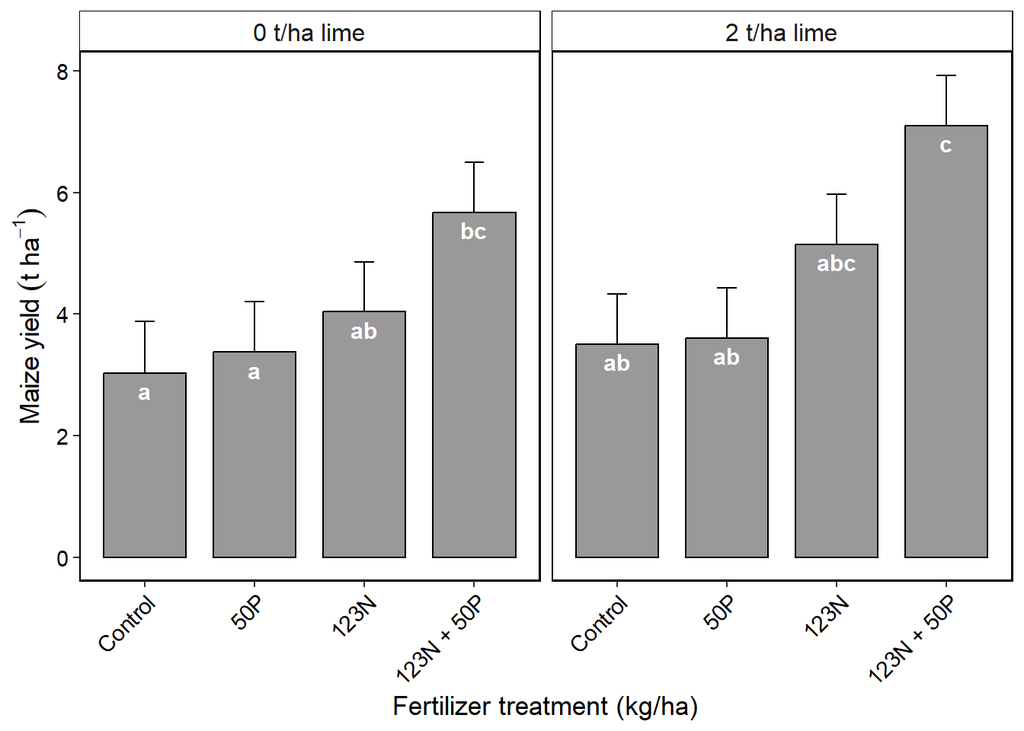

Estimated marginal means of maize yield under lime and fertilizer treatments. Error bars represent standard errors and letters indicate treatment groupings.

```r
# Bar plot of means and SE in two panels - no lime and lime
gy_letters <- gy_letters %>%
  mutate(
    treatment = case_when(
      N_rate == "0"   & P_rate == "0"  ~ "Control",
      N_rate == "0"   & P_rate == "50" ~ "50P",
      N_rate == "123" & P_rate == "0"  ~ "123N",
      N_rate == "123" & P_rate == "50" ~ "123N + 50P"
    ),
    treatment = factor(
      treatment,
      levels = c("Control", "50P", "123N", "123N + 50P")
    ),
    Lime_label = factor(
      Lime_rate,
      levels = c("0", "2"),
      labels = c("0 t/ha lime", "2 t/ha lime")))

yield_bar <- ggplot(gy_letters, aes(x = treatment, y = emmean)) +
  geom_col(fill = "grey60", color = "black", width = 0.75) +
  geom_linerange(aes(ymin = emmean, ymax = emmean + SE), linewidth = 0.5) +
  geom_errorbar(
    aes(ymin = emmean + SE, ymax = emmean + SE),
    width = 0.18, linewidth = 0.5
  ) +
  geom_text(
    aes(label = .group, y = emmean),
    vjust = 1.5, color = "white", fontface = "bold", size = 4
  ) +
  facet_wrap(~ Lime_label, nrow = 1) +
  labs(
    x = "Fertilizer treatment (kg/ha)",
    y = expression(plain(Maize~yield~(t~ha^{-1})))
  ) +
  theme_bw() +
  theme(
    axis.title.x = element_text(face = "plain", size = 13),
    axis.title.y = element_text(face = "plain", size = 13),
    axis.text.x = element_text(color = "black", size = 11, angle = 45, hjust = 1),
    axis.text.y = element_text(color = "black", size = 11),
    strip.text = element_text(face = "plain", size = 12),
    panel.border = element_rect(color = "black", fill = NA, linewidth = 0.8),
    panel.grid = element_blank(),
    strip.background = element_rect(fill = "white", color = "black"))
yield_bar
```

## 1.6 Boxplots of observed yield

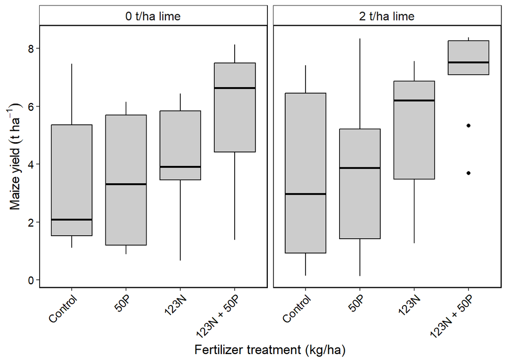

Observed maize yield distribution across fertilizer treatments under 0 and 2 t/ha lime.

```r
# Boxplots
df_plot <- df %>%
  mutate(
    treatment = case_when(
      N_rate == "0"   & P_rate == "0"  ~ "Control",
      N_rate == "0"   & P_rate == "50" ~ "50P",
      N_rate == "123" & P_rate == "0"  ~ "123N",
      N_rate == "123" & P_rate == "50" ~ "123N + 50P"
    ),
    treatment = factor(
      treatment,
      levels = c("Control", "50P", "123N", "123N + 50P")
    ),
    Lime_label = factor(
      Lime_rate,
      levels = c("0", "2"),
      labels = c("0 t/ha lime", "2 t/ha lime")))

yield_box <- ggplot(df_plot, aes(x = treatment, y = GY_tha)) +
  geom_boxplot(fill = "grey80", color = "black", outlier.shape = 16) +
  facet_wrap(~ Lime_label, nrow = 1) +
  labs(
    x = "Fertilizer treatment (kg/ha)",
    y = expression(plain(Maize~yield~(t~ha^{-1})))
  ) +
  theme_bw() +
  theme(
    axis.title.x = element_text(face = "plain", size = 13),
    axis.title.y = element_text(face = "plain", size = 13),
    axis.text.x = element_text(color = "black", size = 11, angle = 45, hjust = 1),
    axis.text.y = element_text(color = "black", size = 11),
    strip.text = element_text(face = "plain", size = 12),
    panel.border = element_rect(color = "black", fill = NA, linewidth = 0.8),
    panel.grid = element_blank(),
    strip.background = element_rect(fill = "white", color = "black"))

yield_box
```

## 1.7 Yield response to post-harvest soil properties

These plots show the relationship between maize yield and selected post-harvest soil properties.

```r
# Plot yield against post harvest soil properties
# Prepare data
df_soil <- semi %>%
  mutate(
    N_rate = factor(n_rate),
    P_rate = factor(p_rate),
    Lime_rate = factor(lime),
    Farmer_code = factor(farmer_code),

    clay_silt_post = clay_post + silt_post,
    ca_sat_post = 100 * ca_cmol_post / ecec_post_cmolkg)

plot_yield_soil <- function(data, soil_var, x_label, model_type = "quadratic"){

  df_plot <- data %>%
    dplyr::select(all_of(soil_var), GY_tha) %>%
    stats::na.omit()

  colnames(df_plot) <- c("x", "y")

  # Means for reference lines
  mean_x <- mean(df_plot$x, na.rm = TRUE)
  mean_y <- mean(df_plot$y, na.rm = TRUE)

  if(model_type == "linear"){
    model <- lm(y ~ x, data = df_plot)
    coefs <- coef(model)
    eq <- paste0(
      "y = ", round(coefs[1], 2),
      ifelse(coefs[2] >= 0, " + ", " - "),
      abs(round(coefs[2], 2)), "x"
    )
    smooth_formula <- y ~ x
  } else {
    model <- lm(y ~ poly(x, 2, raw = TRUE), data = df_plot)
    coefs <- coef(model)
    eq <- paste0(
      "y = ", round(coefs[1], 2),
      ifelse(coefs[2] >= 0, " + ", " - "), abs(round(coefs[2], 2)), "x",
      ifelse(coefs[3] >= 0, " + ", " - "), abs(round(coefs[3], 2)), "x²"
    )
    smooth_formula <- y ~ poly(x, 2, raw = TRUE)
  }

  r2 <- summary(model)$r.squared
  f <- summary(model)$fstatistic
  pval <- pf(f[1], f[2], f[3], lower.tail = FALSE)

  label_text <- paste0(
    eq, "\n",
    "R² = ", round(r2, 2), "\n",
    "p = ", format.pval(pval, digits = 2, eps = 0.001)
  )

  pos_x <- if(soil_var %in% c("ph_post", "ecec_post_cmolkg", "ca_sat_post", "soc_post_pct")) -Inf else Inf
  adj_x <- if(soil_var %in% c("ph_post", "ecec_post_cmolkg", "ca_sat_post", "soc_post_pct")) -0.1 else 1.1

  ggplot(df_plot, aes(x = x, y = y)) +
    geom_point(color = "grey70", size = 1.0, alpha = 0.5) +

    # Mean reference lines
    geom_vline(xintercept = mean_x, linetype = "dashed", color = "grey40", linewidth = 0.1) +
    geom_hline(yintercept = mean_y, linetype = "dashed", color = "grey40", linewidth = 0.1) +

    geom_smooth(
      method = "lm",
      formula = smooth_formula,
      color = "black",
      linewidth = 0.9,
      se = FALSE
    ) +
    #annotate("text", x = pos_x, y = Inf, label = label_text, hjust = adj_x, vjust = 1.4, size = 3.2, fontface = "italic") +

    labs(
      x = x_label,
      y = "Maize yield (t/ha)"
    ) +
    theme_classic() +
    theme(
      axis.title = element_text(face = "plain", size = 11),
      axis.text = element_text(color = "black", size = 10),
      panel.border = element_rect(colour = "black", fill = NA, linewidth = 0.5)
    )
}

p1  <- plot_yield_soil(df_soil, "ph_post", "Soil pH in water", "quadratic")
p2  <- plot_yield_soil(df_soil, "ecec_post_cmolkg", "ECEC (cmolc/kg)", "linear")
p3  <- plot_yield_soil(df_soil, "ex_ac_cmolc_kg_post", "Exchangeable acidity (cmolc/kg)", "quadratic")
p4  <- plot_yield_soil(df_soil, "hp_sat_post_pct", "Acidity saturation (% ECEC)", "linear")
p5  <- plot_yield_soil(df_soil, "ca_sat_post", "Ca saturation (% ECEC)", "linear")
p6  <- plot_yield_soil(df_soil, "soc_post_pct", "SOC (%)", "quadratic")
p7  <- plot_yield_soil(df_soil, "psi_post", "PSI", "quadratic")

final_plot <- (p1 + p2 + p3 + p4 + p5 + p6 + p7) +
  plot_layout(ncol = 3) +
  plot_annotation(tag_levels = "A")
```

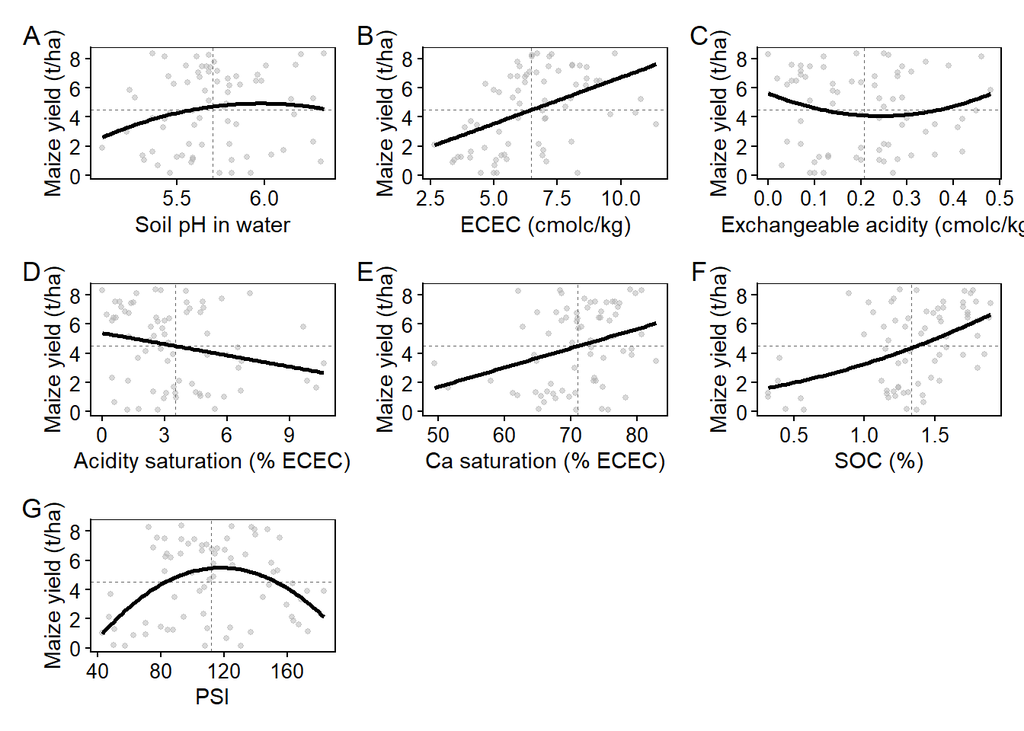

Relationship between maize yield and selected post-harvest soil properties. Vertical lines indicate mean soil property values and horizontal lines indicate mean maize yield.

```r
final_plot
```

## 1.8 Analysis of post-harvest soil properties

The same mixed modelling framework is used to evaluate treatment effects on selected post-harvest soil properties.

```r
# Analyse Post harvest Soil properties of interest (i.e., clay+silt content, SOC, pH, exch Ca, exch Mg, exch acidity, ECEC by sum, acidity saturation, Ca saturation, PSI)
# Helper functions
format_p <- function(p){
  if(is.na(p)) return(NA)
  if(p < 0.001) return("<0.001")
  sprintf("%.3f", p)
}

calc_lsd <- function(em){
  pairs_em <- pairs(em)
  df1 <- summary(em)$df[1]
  tcrit <- qt(0.975, df1)
  SE <- mean(summary(pairs_em)$SE, na.rm = TRUE)
  round(tcrit * SE, 2)
}

calc_cv <- function(model, data, var_name){
  res_sd <- sigma(model)
  mean_val <- mean(data[[var_name]], na.rm = TRUE)
  round((res_sd / mean_val) * 100, 2)
}

# Main function for post-harvest soil properties
run_post_soil_analysis <- function(var_name, data){

  formula_text <- paste(var_name, "~ N_rate * P_rate * Lime_rate + (1 | Farmer_code)")

  model <- tryCatch(
    lmerTest::lmer(as.formula(formula_text), data = data, REML = TRUE),
    error = function(e) return(NULL)
  )

  if(is.null(model)) return(NULL)


  # ANOVA
  anova_tab <- anova(model, type = 3)

  get_p <- function(term){
    if(term %in% rownames(anova_tab)) return(anova_tab[term, "Pr(>F)"])
    else return(NA)
  }

  p_lime <- get_p("Lime_rate")
  p_n    <- get_p("N_rate")
  p_p    <- get_p("P_rate")
  p_np   <- get_p("N_rate:P_rate")
  p_nl   <- get_p("N_rate:Lime_rate")
  p_pl   <- get_p("P_rate:Lime_rate")
  p_npl  <- get_p("N_rate:P_rate:Lime_rate")


  # Estimated marginal means
  em_lime <- emmeans(model, ~ Lime_rate)
  em_n    <- emmeans(model, ~ N_rate)
  em_p    <- emmeans(model, ~ P_rate)
  em_np   <- emmeans(model, ~ N_rate * P_rate | Lime_rate)
  em_all  <- emmeans(model, ~ N_rate * P_rate * Lime_rate)

  # Letters for all 8 treatment combinations
  soil_letters <- multcomp::cld(em_all, Letters = letters) %>%
    as.data.frame() %>%
    mutate(
      .group = trimws(.group),
      omit_treatment = case_when(
        N_rate == "0"   & P_rate == "0"  ~ "Control",
        N_rate == "0"   & P_rate != "0"  ~ "P only",
        N_rate != "0"   & P_rate == "0"  ~ "N only",
        N_rate != "0"   & P_rate != "0"  ~ "N + P"
      ),
      Mean_letter = paste0(round(emmean, 2), " ", .group)
    )

  # Compact table
  results_table <- soil_letters %>%
    dplyr::select(Lime_rate, omit_treatment, Mean_letter) %>%
    pivot_wider(names_from = omit_treatment, values_from = Mean_letter) %>%
    arrange(Lime_rate)

  # CV
  cv_val <- calc_cv(model, data, var_name)

  # Statistics rows
  stats_tab <- tibble(
    Lime_rate = c("Lime", "N fertilizer", "P fertilizer", "N x P", "N x Lime", "P x Lime", "N x P x Lime", "CV (%)"),
    `Control` = c(
      ifelse(!is.na(p_lime) & p_lime <= 0.05,
             paste0(calc_lsd(em_lime), " (", format_p(p_lime), ")"),
             paste0("ns (", format_p(p_lime), ")")),

      ifelse(!is.na(p_n) & p_n <= 0.05,
             paste0(calc_lsd(em_n), " (", format_p(p_n), ")"),
             paste0("ns (", format_p(p_n), ")")),

      ifelse(!is.na(p_p) & p_p <= 0.05,
             paste0(calc_lsd(em_p), " (", format_p(p_p), ")"),
             paste0("ns (", format_p(p_p), ")")),

      ifelse(!is.na(p_np) & p_np <= 0.05,
             paste0(calc_lsd(em_np), " (", format_p(p_np), ")"),
             paste0("ns (", format_p(p_np), ")")),

      paste0("ns (", format_p(p_nl), ")"),
      paste0("ns (", format_p(p_pl), ")"),
      paste0("ns (", format_p(p_npl), ")"),
      as.character(cv_val)
    ),
    `N only` = NA,
    `P only` = NA,
    `N + P` = NA
  )

  summary_table <- bind_rows(results_table, stats_tab) %>%
    mutate(Variable = var_name, .before = 1)

  # Means export table
  means_export <- soil_letters %>%
    dplyr::select(
      Lime_rate, N_rate, P_rate, omit_treatment,
      emmean, SE, df, lower.CL, upper.CL, .group
    ) %>%
    dplyr::rename(
      Lime = Lime_rate,
      N = N_rate,
      P = P_rate,
      Treatment = omit_treatment,
      Mean = emmean,
      Letters = .group
    ) %>%
    mutate(Variable = var_name, .before = 1)

  # ANOVA export
  anova_export <- as.data.frame(anova_tab) %>%
    tibble::rownames_to_column("Term") %>%
    mutate(Variable = var_name, .before = 1)

  return(list(
    means = means_export,
    compact = results_table %>% mutate(Variable = var_name, .before = 1),
    summary = summary_table,
    anova = anova_export
  ))
}

post_soil_vars <- c(
  "clay_silt_post","soc_post_pct",
  "ph_post","ca_cmol_post",
  "mg_cmol_post","ex_ac_cmolc_kg_post",
  "ecec_post_cmolkg","hp_sat_post_pct",
  "ca_sat_post","psi_post")

soil_results_list <- purrr::map(post_soil_vars, ~ run_post_soil_analysis(.x, df_soil))

soil_means <- purrr::map_dfr(soil_results_list, "means")
soil_compact <- purrr::map_dfr(soil_results_list, "compact")
soil_summary <- purrr::map_dfr(soil_results_list, "summary")
soil_anova <- purrr::map_dfr(soil_results_list, "anova")
```

### 1.8.1 Post-harvest soil summary table

```r
soil_summary %>%
  gt() %>%
  tab_header(
    title = md("**Summary table for post-harvest soil properties**")
  ) %>%
  cols_align(
    align = "center",
    columns = everything()
  ) %>%
  tab_source_note(
    source_note = md(
      "*Note:* Values in the main body of the table are treatment means followed by grouping letters for each post-harvest soil property. For the summary rows, LSD values are reported only where the corresponding treatment effect was significant at *p* ≤ 0.05, with *p*-values shown in parentheses. `ns` indicates not significant. `CV (%)` denotes the coefficient of variation.")
  ) %>%
  tab_options(
    table.font.size = 11,
    data_row.padding = px(3),
    heading.align = "center")
```

Summary table for post-harvest soil properties across treatments.

**Summary table for post-harvest soil properties**

| Variable | Lime_rate | N only | P only | N + P | Control |
| --- | --- | --- | --- | --- | --- |
| clay_silt_post | 0 | 79.05 a | 80.36 a | 79.11 a | 79.37 a |
| clay_silt_post | 2 | 77.26 a | 77.74 a | 77.76 a | 78.29 a |
| clay_silt_post | Lime | NA | NA | NA | 1.59 (0.016) |
| clay_silt_post | N fertilizer | NA | NA | NA | ns (0.355) |
| clay_silt_post | P fertilizer | NA | NA | NA | ns (0.721) |
| clay_silt_post | N x P | NA | NA | NA | ns (0.968) |
| clay_silt_post | N x Lime | NA | NA | NA | ns (0.838) |
| clay_silt_post | P x Lime | NA | NA | NA | ns (0.694) |
| clay_silt_post | N x P x Lime | NA | NA | NA | ns (0.475) |
| clay_silt_post | CV (%) | NA | NA | NA | 3.73 |
| soc_post_pct | 0 | 1.32 ab | 1.25 ab | 1.15 a | 1.27 ab |
| soc_post_pct | 2 | 1.34 ab | 1.44 b | 1.41 b | 1.35 ab |
| soc_post_pct | Lime | NA | NA | NA | 0.09 (<0.001) |
| soc_post_pct | N fertilizer | NA | NA | NA | ns (0.497) |
| soc_post_pct | P fertilizer | NA | NA | NA | ns (0.861) |
| soc_post_pct | N x P | NA | NA | NA | ns (0.279) |
| soc_post_pct | N x Lime | NA | NA | NA | ns (0.916) |
| soc_post_pct | P x Lime | NA | NA | NA | ns (0.032) |
| soc_post_pct | N x P x Lime | NA | NA | NA | ns (0.413) |
| soc_post_pct | CV (%) | NA | NA | NA | 12.68 |
| ph_post | 0 | 5.56 a | 5.65 a | 5.62 a | 5.61 a |
| ph_post | 2 | 5.84 a | 5.79 a | 5.79 a | 5.73 a |
| ph_post | Lime | NA | NA | NA | 0.11 (<0.001) |
| ph_post | N fertilizer | NA | NA | NA | ns (0.878) |
| ph_post | P fertilizer | NA | NA | NA | ns (0.560) |
| ph_post | N x P | NA | NA | NA | ns (0.636) |
| ph_post | N x Lime | NA | NA | NA | ns (0.374) |
| ph_post | P x Lime | NA | NA | NA | ns (0.644) |
| ph_post | N x P x Lime | NA | NA | NA | ns (0.568) |
| ph_post | CV (%) | NA | NA | NA | 3.74 |

[output cut: 70 more lines]

```r
writexl::write_xlsx(
  list(
    "Means_with_letters" = soil_means,
    "Compact_table" = soil_compact,
    "Summary_table" = soil_summary,
    "ANOVA" = soil_anova
  ),
  "Semi_omissions_post_soil_analysis.xlsx")
```